# An Interactive Introduction to R Shiny

Cheng Peng

12/18/2021

# 1 What is Shiny?

Shiny is a package from RStudio that can be used to build **interactive** web pages with R without assuming any prior experience with web development, and you do not need to know any HTML/CSS/JavaScript.

We can us R Shiny to make an interactive web page that can seamlessly interact with R and display R objects (plots, tables, of anything else you do in R).

[figure not shown]

```r
include_graphics("../RShiny/ShinyImg/uiserver.png")
```

In this note, we’ll walk through all the steps of building a Shiny app using a data set to illustrate these steps. If you want even more practice, you can check the official Shiny tutorial https://shiny.rstudio.com/tutorial/. RStudio also provides a handy cheat-sheet https://shiny.rstudio.com/images/shiny-cheatsheet.pdf with detailed Shiny commands.

# 2 Preparation

We need to have the shiny package, so install it. Since we use R Markdown to prepare this note, we should also install knitr package.

```r
if (!require("knitr")) {
   install.packages("knitr")
   library(knitr)
}
if (!require("shiny")) {
   install.packages("shiny")
   library(shiny)
}
```

To ensure that Shiny is successfully installed, we try to run one of the demo apps.

```r
library(shiny)
#runExample("01_hello")  # test whether the package was istalled.
```

Press Escape to close the app if a pop-up web page appears. We are ready to build our first Shiny app!

# 3 Shiny App Basics

Shiny applications have two components, a web-based user interface object that shows the app to the user and a server function running on a computer (such as our local machine or a remote server). We need to write the source code for these two parts. In Shiny terminology, they are called UI (user interface) and server.

**UI Function** is just a web document that the user gets to see, it’s HTML that you write using Shiny’s functions. The UI is responsible for creating the layout of the app and telling Shiny exactly where things go.

**Server Function** is responsible for the logic of the app; it’s the set of instructions that tell the web page what to show when the user interacts with the page.

The UI is responsible for creating these controls and telling Shiny where to place the controls and where to place the plot and table, while the server is responsible for creating the actual plot or the data in the table.

# 4 Shiny App Template

There are three different to layout a shiny app.

## 4.1 Create A Template of Shiny App

All Shiny apps follow the same template that has no content.

```r
library(shiny)
ui <- fluidPage()
server <- function(input, output) {}
shinyApp(ui = ui, server = server)
```

Several important things we should keep in mind:

- It is very important that the name of the file is `app.R`, otherwise it would not be recognized as a Shiny app.
- We should not have any R code after the `shinyApp(ui = ui, server = server)` line. That line needs to be the last line in your file.
- It is good practice to place this app in its own folder, and not in a folder that already has other R scripts or files, unless those other files are used by your app.

After saving the file, RStudio should recognize that this is a Shiny app, and we will see the usual Run button at the top change to Run App.

## 4.2 Separate UI and Server Files

Another way to define a Shiny app is by separating the UI and server code into two files: `ui.R` and `server.R`. This is the preferable way to write Shiny apps when the app is complex and involves more code.

If we want to break up your app into these two files, you simply put all code that is assigned to the ui variable in `ui.R` and all the code assigned to the server function in `server.R`.

Note that when using this method (instead of having one app.R file), we do not need to include the code line `shinyApp(ui = ui, server = server)`.

## 4.3 Shiny App Template

We can also create a new Shiny app using RStudio’s menu by selecting

`File > New File > Shiny Web App….`

RStudio will let us choose if we want a single-file app (app.R) or a two-file app (ui.R+server.R). RStudio will initialize a simple functional Shiny app with some code in it.

# 5 Loading Datasets

The dataset we’ll be using contains information about all the products sold by BC Liquor Store and is provided by OpenDataBC. A subset of the data file can be found at https://stat553.s3.amazonaws.com/Shiny/bcl-data.csv

```r
bcl <- read.csv("https://stat553.s3.amazonaws.com/Shiny/bcl-data.csv", stringsAsFactors = FALSE)
```

Place this line in the app as the second line, just after library(shiny). We can type the following command to see the detailed information about the variables in the data set.

```r
print(str(bcl))
```

```
## 'data.frame':    6132 obs. of  7 variables:
##  $ Type           : chr  "WINE" "WINE" "WINE" "WINE" ...
##  $ Subtype        : chr  "TABLE WINE RED" "TABLE WINE WHITE" "TABLE WINE RED" "TABLE WINE WHITE" ...
##  $ Country        : chr  "CANADA" "CANADA" "CANADA" "CANADA" ...
##  $ Name           : chr  "COPPER MOON - MALBEC" "DOMAINE D'OR - DRY" "SOMMET ROUGE" "MISSION RIDGE - PREMIUM DRY WHITE" ...
##  $ Alcohol_Content: num  14 11.5 12 11 13.5 11 12.5 12 11.5 40 ...
##  $ Price          : num  31 33 30 34 37 ...
##  $ Sweetness      : int  0 0 0 1 0 0 0 0 0 NA ...
## NULL
```

Please keep in mind that this line of code should not be placed in the app.

# 6 Buildiung UI

Let’s start populating our app with some elements visually. This is usually the first thing you do when writing a Shiny app - add elements to the UI. Recall the following template of shiny app.

```
library(shiny)
ui <- fluidPage()
server <- function(input, output) {}
shinyApp(ui = ui, server = server)
```

## 6.1 Add Plain Text to UI

You can place R strings inside `fluidPage()` to render text.

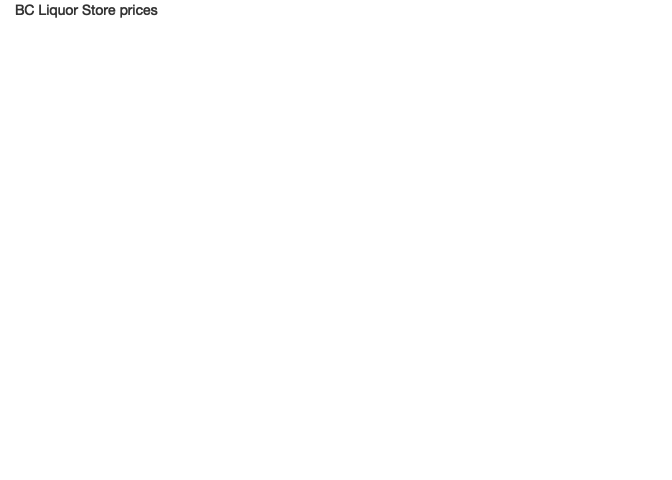

```r
library(shiny)
ui <- fluidPage("BC Liquor Store", "prices")  # add text to the app
server <- function(input, output) {}
shinyApp(ui = ui, server = server)
```

Since the entire UI is built by passing comma-separated arguments into the `fluidPage()` function, By passing regular text, the web page just rendered boring unformatted text.

## 6.2 Add Formatted Text and Other HTML Elements

If we want our text to be formatted nicer, Shiny has many functions that are wrappers around HTML tags that format text. We can use the following HTML commands to formatted the added text.

- `h1()` function for a top-level header (`<h1> in HTML`),
- `h2()` for a secondary header (`<h2> in HTML`),
- `strong()` to make text bold (`<strong> in HTML`),
- `em()` to make text italicized (`<em> in HTML`), and many more.

There are also functions that are wrappers to other HTML tags, such as

- `br()` for a line break,
- `img()` for an image,
- `a()` for a hyperlink, and others.

All of these functions are actually just wrappers to HTML tags with the equivalent name. You can add any arbitrary HTML tag using the tags object, which you can learn more about by reading the help file on tags.

Just as a demonstration, try replacing the `fluidPage()` function in your UI with

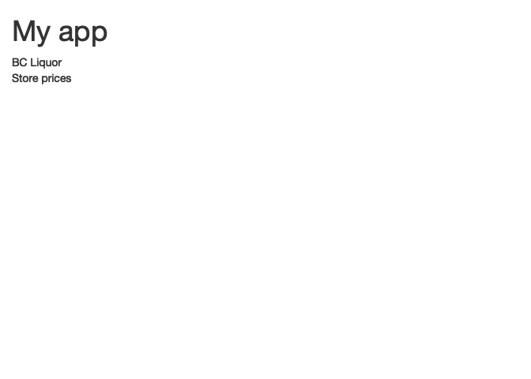

```r
# UI function
ui = fluidPage(
    h1("My app"),   # level 1 header
    "BC",
    "Liquor",
  br(),             # break line
  "Store",
  strong("prices")  # bold face
)

## Server function
server <- function(input, output) {}
##
shinyApp(ui = ui, server = server)
```

For those who know basic HTML: run the `fluidPage(...)` function in the console and see the HTML that it creates.

That means that we can, for example, create blue text with `div("this is blue", style = "color: blue;")`.

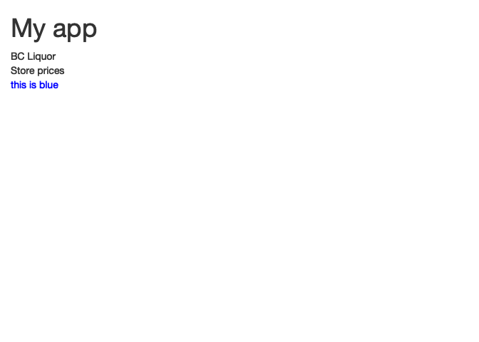

```r
# UI function
ui = fluidPage(
    h1("My app"),   # level 1 header
    "BC",
    "Liquor",
  br(),             # break line
  "Store",
  strong("prices"), # bold face
  br(),
  div("this is blue", style = "color: blue;")  # add colors to the text
)

## Server function
server <- function(input, output) {}
##
shinyApp(ui = ui, server = server)
```

## 6.3 Add A Title

We could add a title to the app with `h1()`, but Shiny also has a special function `titlePanel()`. Using `titlePanel()` not only adds a visible big title-like text to the top of the page, but it also sets the “official” title of the web page. This means that when you look at the name of the tab in the browser, we’ll see this title.

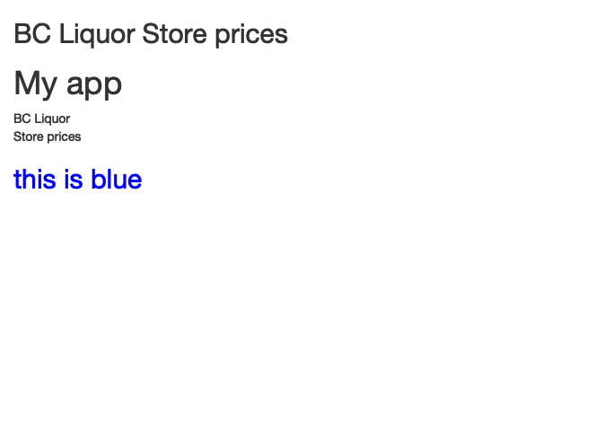

```r
# UI function
ui = fluidPage(
    titlePanel("BC Liquor Store prices"),
    ##
    h1("My app"),   # level 1 header
    "BC",
    "Liquor",

    br(),             # break line
    "Store",
    strong("prices"), # bold face
    br(),
    div(h2("this is blue"), style = "color: blue;")  # add colors to the text
)

## Server function
server <- function(input, output) {}
##
shinyApp(ui = ui, server = server)
```

## 6.4 Add A Layout

So far, everything added to the UI is unstructured and the elements simply stack up one below the other in one column. We’ll use `sidebarLayout()` to add a simple structure.

It provides a simple two-column layout with a smaller **sidebar** and a **larger main panel**. We’ll build our app such that all the inputs that the user can manipulate will be in the **sidebar** on the **left**, and the results will be shown in the **main panel** on the **right**.

Remember that all the arguments inside `fluidPage()` need to be separated by commas. So far our complete app looks like this (hopefully this isn’t a surprise to you)

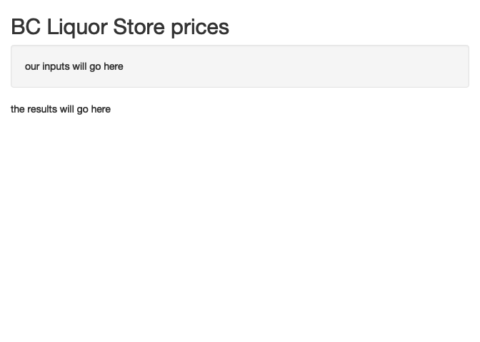

```r
library(shiny)
bcl <- read.csv("https://stat553.s3.amazonaws.com/Shiny/bcl-data.csv", stringsAsFactors = FALSE)
###
ui <- fluidPage(
  titlePanel("BC Liquor Store prices"),
  sidebarLayout(
    sidebarPanel("our inputs will go here"),
    mainPanel("the results will go here")
  )
)
###
server <- function(input, output) {}
###
shinyApp(ui = ui, server = server)
```

**Shiny layout**: we add much more fine control over where things go by using a grid layout.

## 6.5 UI Functions - HTML Wrappers

As mentioned earlier, the entire UI is just HTML, and Shiny simply gives you easy tools to write it without having to know HTML. For example, we type the `ui` in the R Console, you will the following HTML code.

```
 <div class="container-fluid">
   <h2>BC Liquor Store prices</h2>
   <div class="row">
     <div class="col-sm-4">
       <form class="well">our inputs will go here</form>
     </div>
     <div class="col-sm-8">the results will go here</div>
   </div>
 </div>
```

# 7 Add Inputs to the UI

Inputs are what gives users a way to interact with a Shiny app. Shiny provides many input functions to support many kinds of interactions that the user could have with an app.

- `textInput()` is used to let the user enter text,
- `numericInput()` lets the user select a number,
- `dateInput()` is for selecting a date, *`selectInput()` is for creating a select box (aka a dropdown menu).

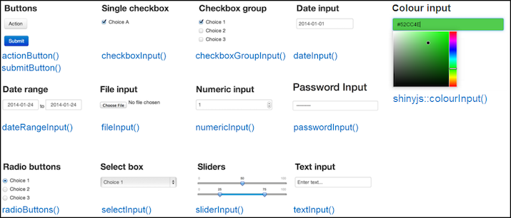

```r
include_graphics("../RShiny/ShinyImg/shiny-inputs.png")
```

All input functions have the same first two arguments: `inputId` and label. The `inputId` will be the name that Shiny will use to refer to this input when you want to retrieve its current value.

It is important to note that every input must have a unique `inputId`. If you give more than one input the same id, Shiny will unfortunately not give us an explicit error, but our app won’t work correctly.

The `label argument` specifies the text in the display label that goes along with the input widget.

## 7.1 Input for Price

The first input we want to have is for specifying a price range (minimum and maximum price). The most sensible types of input for this are either `numericInput()` or `sliderInput()` since they are both used for selecting numbers.

If we use `numericInput()`, we’d have to use two inputs, one for the minimum value and one for the maximum.

To create a `slider input`, a maximum value needs to be provided. We could use the maximum price in the data set.

```
sliderInput("priceInput", "Price",
             min = 0,
             max = 100,
             value = c(25, 40),
             pre = "$")
```

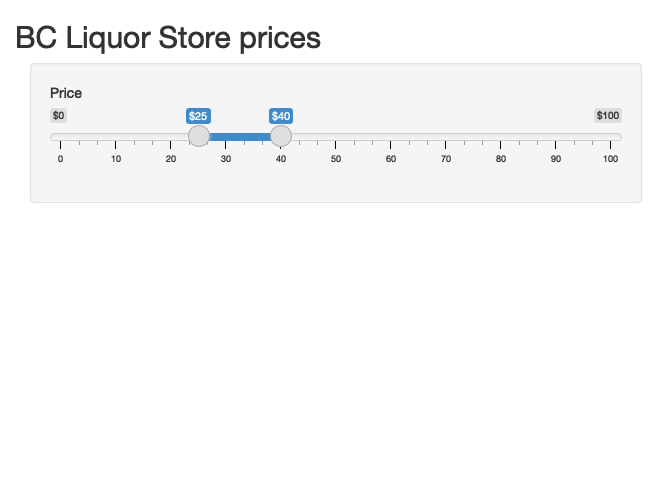

```r
library(shiny)
bcl <- read.csv("https://stat553.s3.amazonaws.com/Shiny/bcl-data.csv", stringsAsFactors = FALSE)
###
ui <- fluidPage(
  titlePanel("BC Liquor Store prices"),
  sidebarPanel( # There could be multiple input widgets within siderbarPanel.
     sliderInput("priceInput", "Price",
             min = 0,
             max = 100,
             value = c(25, 40),
             pre = "$")
     )
)
###
server <- function(input, output) {}
###
shinyApp(ui = ui, server = server)
```

Place the code for the slider input inside `sidebarPanel()`. There could be multiple input widgets within `siderbarPanel`.

## 7.2 Input for Product Type

Usually when going to the liquor store we know exactly the type of wine we want to buy and don’t want to waste time in the wrong section. The same is true in our app, we should be able to choose what type of product we want.

We could either use either `radio buttons` or a `select box` for our purpose. Let’s use radio buttons for now since there are only a few options, so take a look at the documentation for `radioButtons()` and come up with a reasonable input function code.

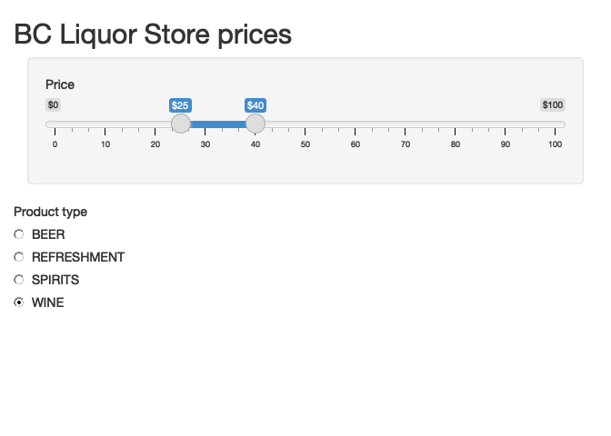

```r
library(shiny)
bcl <- read.csv("https://stat553.s3.amazonaws.com/Shiny/bcl-data.csv", stringsAsFactors = FALSE)
###
ui <- fluidPage(
  titlePanel("BC Liquor Store prices"),
  sidebarPanel( # There could be multiple input widgets within siderbarPanel.
     sliderInput("priceInput", "Price",
             min = 0,
             max = 100,
             value = c(25, 40),
             pre = "$")
     ),
  radioButtons("typeInput", "Product type",
            choices = c("BEER", "REFRESHMENT", "SPIRITS", "WINE"),
            selected = "WINE")
)
###
server <- function(input, output) {}
###
shinyApp(ui = ui, server = server)
```

Again, add input code `radioButtons` inside `sidebarPanel()`.

If we look at that input function and think “what if there were 100 types, listing them by hand would not be fun, there’s got to be a better way!”, then we’re right. This is where `uiOutput()` comes in handy, but we’ll talk about that later.

## 7.3 Input for Country

Sometimes we only look for wines imported from France. We then should add one last input, to select a country. The most appropriate input type in this case is probably the select box using `selectInput()` to create dropdown input function.

Assume that we have CANADA, FRANCE, ITALY as options, and later we’ll see how to include all countries. The code is given below

```
selectInput("countryInput", "Country",
            choices = c("CANADA", "FRANCE", "ITALY"))
```

Add this function as well to our App (with aforementioned input widgets).

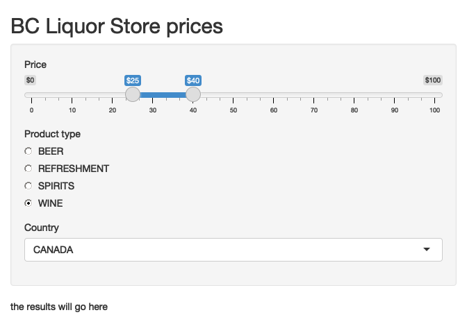

```r
library(shiny)
bcl <- read.csv("https://stat553.s3.amazonaws.com/Shiny/bcl-data.csv", stringsAsFactors = FALSE)
###
ui <- fluidPage(
  titlePanel("BC Liquor Store prices"),
  sidebarLayout(
    sidebarPanel(
      sliderInput("priceInput", "Price", 0, 100, c(25, 40), pre = "$"),
      radioButtons("typeInput", "Product type",
                  choices = c("BEER", "REFRESHMENT", "SPIRITS", "WINE"),
                  selected = "WINE"),
      selectInput("countryInput", "Country",
                  choices = c("CANADA", "FRANCE", "ITALY"))
    ),
    mainPanel("the results will go here")
  )
)
###
server <- function(input, output) {}
###
shinyApp(ui = ui, server = server)
```

# 8 Add Placeholders for Outputs

After creating all the inputs, we should add elements to the UI to display the **outputs**. Outputs can be any object that R creates and that we want to display in our app - such as a plot, a table, or text.

We’re still only building the UI, so at this point we can only add placeholders for the outputs that will determine where an output will be and what its ID is, but it won’t actually show anything.

Shiny provides several output functions, one for each type of output. Similarly to input functions, all output functions have a `outputId` argument that is used to identify each output, and this argument must be `unique` for each output.

## 8.1 Output for A Plot

At the top of the **main panel** we’ll have a plot showing some visualization of the results. Since we want a plot, the function we use is `plotOutput()`.

Add the following code into the `mainPanel()`:

```r
plotOutput("coolplot")
```

This will add a placeholder in the UI for a plot named **coolplot**.

## 8.2 Output for A Table Summary

Below the plot, we will have a table that shows all the results. To get a table, we use the `tableOutput()` function.

Here is a simple way to create a UI element that will hold a table output:

```
tableOutput("results")
```

Add this output to the `mainPanel()` as well. Maybe add a couple `br()` in between the two outputs, just as a space buffer so that they aren’t too close to each other.

# 9 Checkpoint: what our app looks like after implementing the UI

If you’ve followed along, your app should now have this code:

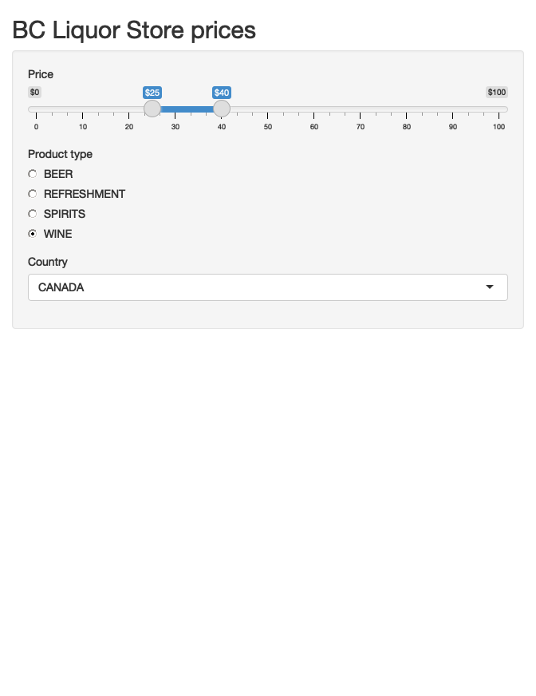

```r
library(shiny)
# global statement
bcl <- read.csv("https://stat553.s3.amazonaws.com/Shiny/bcl-data.csv", stringsAsFactors = FALSE)
# ui
ui <- fluidPage(
  ## title panel
  titlePanel("BC Liquor Store prices"),
  ## sidebar layout
  sidebarLayout(
    sidebarPanel(
         ### input widget 1
         sliderInput("priceInput", "Price", 0, 100, c(25, 40), pre = "$"),
         ### input widget 2
         radioButtons("typeInput", "Product type",
                  choices = c("BEER", "REFRESHMENT", "SPIRITS", "WINE"),
                  selected = "WINE"),
         ### input widget 3
         selectInput("countryInput", "Country",
                  choices = c("CANADA", "FRANCE", "ITALY"))
         ),
     ## Main Panel for outputs
     mainPanel(
         plotOutput("coolplot"), # output place holder 1
         br(),                   # separate
         br(),
         tableOutput("results")  # output place holder 2
       )
  )   # close sidebarLyout
)     # close ui
##
server <- function(input, output) {}
##
shinyApp(ui = ui, server = server)
```

# 10 Implement Server Logic to Display Outputs

Now we have to write the server function, which will be responsible for listening to changes to the inputs and creating outputs to show in the app.

Since the server function has two arguments: **input** and **output**, we must define these two arguments!

**input** is a list we will read values from and **output** is a list we will write values to.

- **input** will contain the values of all the different inputs at any given time;
- **output** is where we will save output objects (such as tables and plots) to display in the app.

## 10.1 Building An Output

Recall that we created two output placeholders: **coolplot** (a plot) and **results** (a table). We need to write code in R that will tell Shiny what kind of plot or table to display.

There are three rules to build an output in Shiny.

1. Save the output object into the output list (remember the app template - every server function has an output argument)
2. Build the object with a `render*` function, where `*` is the type of output, such as `renderPlot`, `renderTable`, `renderImage`, etc.
3. Access input values using the input list (every server function has an input argument)

The third rule is only required if we want our output to depend on some input. Let’s first see how to build a very basic output using only the first two rules. We’ll create a plot and send it to the coolplot output.

```
output$coolplot <- renderPlot({
      plot(rnorm(100))
    })
```

This simple code shows the first two rules: we’re creating a plot inside the `renderPlot()` function, and assigning it to **coolplot** in the output list.

Remember that every output created in the UI must have a unique ID, now we see why. In order to attach an R object to an output with ID `x`, we assign the R object to `output$x`.

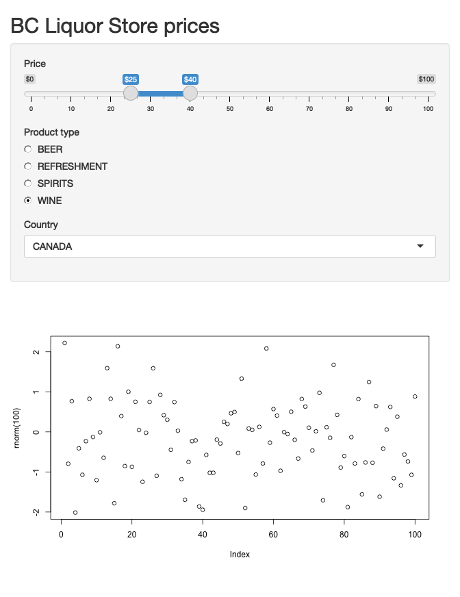

```r
library(shiny)
# ui
ui <- fluidPage(
  ## title panel
  titlePanel("BC Liquor Store prices"),
  ## sidebar layout
  sidebarLayout(
    sidebarPanel(
         ### input widget 1
         sliderInput("priceInput", "Price", 0, 100, c(25, 40), pre = "$"),
         ### input widget 2
         radioButtons("typeInput", "Product type",
                  choices = c("BEER", "REFRESHMENT", "SPIRITS", "WINE"),
                  selected = "WINE"),
         ### input widget 3
         selectInput("countryInput", "Country",
                  choices = c("CANADA", "FRANCE", "ITALY"))
         ),
     ## Main Panel for outputs
     mainPanel(
         plotOutput("coolplot"), # output place holder 1
         br(),                   # separate
         br(),
         tableOutput("results")  # output place holder 2
       )
  )   # close sidebarLyout
)     # close ui
##
server <- function(input, output) {
       output$coolplot <- renderPlot({
           plot(rnorm(100))
       })
}
##
shinyApp(ui = ui, server = server)
```

## 10.2 Making An Output That Reacts to An Input

Instead of always plotting the same plot (100 random numbers) in the previous example, let’s make an output plot based on working data set so that the output plots will change based on the input information via various input widgets.

```
output$coolplot <- renderPlot({
  plot(rnorm(input$priceInput[1])),
  plot(rnorm(input$priceInput[2]))
})
```

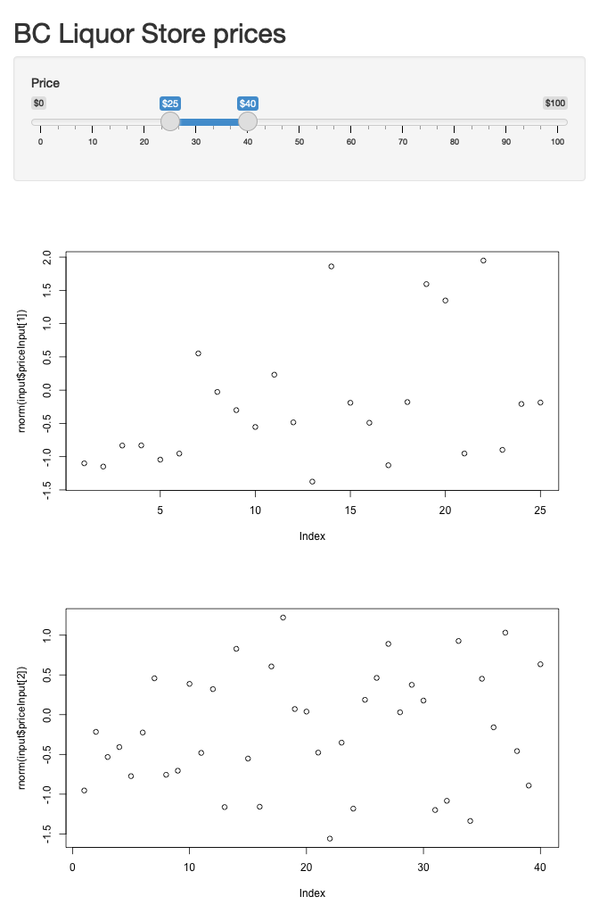

```r
library(shiny)
# global statement
bcl <- read.csv("https://stat553.s3.amazonaws.com/Shiny/bcl-data.csv", stringsAsFactors = FALSE)
# ui
ui <- fluidPage(
  ## title panel
  titlePanel("BC Liquor Store prices"),
  ## sidebar layout
  sidebarLayout(
    sidebarPanel(
         ### input widget 1
         sliderInput("priceInput", "Price", 0, 100, c(25, 40), pre = "$"),
         ),
     ## Main Panel for outputs
     mainPanel(
         plotOutput("coolplot"), # output place holder 1
         plotOutput("coolplot2") # output place holder 1
       )
  )   # close sidebarLyout
)     # close ui
##
server <- function(input, output) {
  output$coolplot <- renderPlot({
         plot(rnorm(input$priceInput[1]))
      })
     br()
    output$coolplot2 <- renderPlot({
         plot(rnorm(input$priceInput[2]))
      })
}
##
shinyApp(ui = ui, server = server)
```

Whenever we choose a new minimum price range , the first plot will update with a new number of points but not the second plot and vice versa.

`input$priceInput` return a vector of length 2 containing the miminimum and maximum price. Whenever the user manipulates the slider in the app, these values are updated, and whatever code relies on it gets re-evaluated. This is a concept known as **reactivity**, which we will get to in a few minutes.

## 10.3 Building the plot output

We mow create a simple histogram of the alcohol content of the products by using the same 3 rules to create a plot output using package `ggplot()`.

The alcohol content is dependent on the price, wine type, and the country where the wine was produced. Therefore, we have 3 inputs: `priceInput`, `typeInput`, and `countryInput` that are defined in **ui()**.

We can filter the data based on the values of these three inputs. We’ll use `dplyr` functions to filter the data, so be sure to include `dplyr` at the top. Then we’ll plot the filtered data instead of the original data using the following code.

```
output$coolplot <- renderPlot({
  filtered <-
    bcl %>%
    filter(Price >= input$priceInput[1],
           Price <= input$priceInput[2],
           Type == input$typeInput,
           Country == input$countryInput
    )
  ggplot(filtered, aes(Alcohol_Content)) +
    geom_histogram()
})
```

To make sure we’re on the same page, here is what our code should look like at this point:

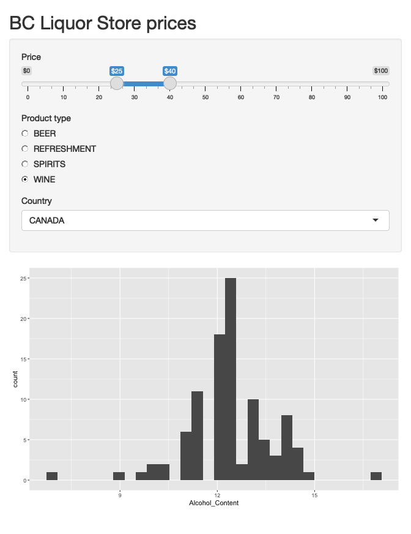

```r
library(shiny)
library(ggplot2)
library(dplyr)

bcl <- read.csv("https://stat553.s3.amazonaws.com/Shiny/bcl-data.csv", stringsAsFactors = FALSE)

ui <- fluidPage(
  titlePanel("BC Liquor Store prices"),
  sidebarLayout(
    sidebarPanel(
      sliderInput("priceInput", "Price", 0, 100, c(25, 40), pre = "$"),
      radioButtons("typeInput", "Product type",
                  choices = c("BEER", "REFRESHMENT", "SPIRITS", "WINE"),
                  selected = "WINE"),
      selectInput("countryInput", "Country",
                  choices = c("CANADA", "FRANCE", "ITALY"))
    ),
    mainPanel(
      plotOutput("coolplot"),
      br(), br(),
      tableOutput("results")
    )
  )
)

server <- function(input, output) {
  output$coolplot <- renderPlot({
    filtered <-
      bcl %>%
      filter(Price >= input$priceInput[1],
             Price <= input$priceInput[2],
             Type == input$typeInput,
             Country == input$countryInput
      )
    ggplot(filtered, aes(Alcohol_Content)) +
      geom_histogram()
  })
}

shinyApp(ui = ui, server = server)
```

## 10.4 Building Table Outputs

The other output we have was called **results** (as defined in the UI) and should be a table of all the products that match the filters.

Since it’s a table output, we should use the `renderTable()` function. We’ll do the exact same filtering on the data, and then simply return the data as a data.frame. Shiny will know that it needs to display it as a table because it’s defined as a `tableOutput`.

The code for creating the table output has the following form

```
output$results <- renderTable({
  filtered <-
    bcl %>%
    filter(Price >= input$priceInput[1],
           Price <= input$priceInput[2],
           Type == input$typeInput,
           Country == input$countryInput
    )
  filtered
})
```

We add this code to the server function. Don’t overwrite the previous definition of `output$coolplot`, just add this code before or after that, but inside the server function.

# 11 Basics of Reactivity

Shiny uses a concept called `reactive programming`. This is what enables our outputs **to react** to changes in inputs.

Reactivity in Shiny is complex, but as an extreme oversimplification, it means that when the value of a variable x changes, then anything that relies on x gets re-evaluated.

Consider the following code:

```
x <- 5
y <- x + 1
x <- 10
```

What is the value of y? It’s 6. But in reactive programming, if x and y are reactive variables, then the value of y would be 11 because it would be updated whenever x is changed.

Only reactive variables behave this way, and in Shiny all inputs are automatically reactive. That’s why you can always use `input$x` in render functions, and you can be sure that whatever output depends on `x` will use the updated value of `x` whenever `x` changes.

Consider the following sample code to create a plot with a specific number of points in a specific color:

```
output$someoutput <- renderPlot({
  col <- input$mycolour
  num <- input$mynumber
  plot(rnorm(num), col = col)
})
```

The above render function accesses two different inputs: `input$mycolour` and `input$mynumber`. This means that this code block depends on both of these variables, so whenever either one of the two inputs is updated, the code gets re-executed with the new input values and `output$someoutput` is updated.

## 11.1 Creating And Accessing Reactive Variables

One very important thing to remember about reactive variables (such as the input list) is that they can only be used inside reactive contexts. Any `render*` function is a reactive context, so we can always use `input$x` or any other reactive variable inside render functions.

There are two other common reactive contexts that we’ll get to shortly: **reactive({})** and **observe({})**.

To show what this means, we access the price input value in the server function, without explicitly being inside a reactive context. Simply add print(`input$priceInput`) inside the server function, and we will get an error when running the app. Shiny is very clear about what the error is: we are trying to access a reactive variable outside of a reactive context.

To fix this, we can use the `observe({})` function to access the input variable. Inside the server, replace `print(input$priceInput)` with `observe({ print(input$priceInput) })`, and now the app should run fine. Note that this `observe({})` statement depends on `input$priceInput`, so whenever we change the value of the price, the code inside this `observe({})` will run again, and the new value will be printed.

This is actually a very simple yet useful debugging technique in Shiny: often we want to know what value a reactive variable holds, so we need to remember to wrap the `cat(input$x)` or `print(input$x)` by an `observe({})`.

We can also create our own reactive variables using the `reactive({})` function. The `reactive({})` function is similar to `observe({})` in that it is also a reactive context, which means that it will get re-run whenever any of the reactive variables in it get updated.

The difference between them is that `reactive({})` returns a value. To see it in action, let’s **create** a variable called `priceDiff` that will be the difference between the maximum and minimum price selected. If we try to naively define

`priceDiff <- diff(input$priceInput)`.

We’ll see the same error as before about doing something outside a reactive context. This is because `input$priceInput` is a reactive variable, and we can’t use a reactive variable outside a reactive context. Since we want to assign a value, we use the `reactive({})` function. Try adding the following line to your server:

```
priceDiff <- reactive({
  diff(input$priceInput)
})
```

If we want to access a reactive variable defined with `reactive({})`, we must add parentheses after the variable name, as if it’s a function.

To demonstrate this, add `observe({ print(priceDiff()) })` to our server function. Notice that we use `priceDiff()` rather than `priceDiff`. It’s very important to remember this, because we can get confusing unclear errors if we simply try to access a custom reactive variable without the parentheses.

We can think of `reactivity` as causing a chain reaction: when one reactive value changes, anything that depends on it will get updated. If any of the updated values are themselves reactive variables, then any reactive contexts that depend on those variables will also get updated in turn.

As a concrete example, let’s think about what happens when we change the value of the `priceInput` on the page. Since `input$priceInput` is a reactive variable, any expression that uses it will get updated. This means the two render functions from earlier will execute because they both depend on `input$priceInput`, as well as the `priceDiff` variable because it also depends on it.

Since priceDiff is itself a reactive variable, Shiny will check if there is anything that depends on `priceDiff`, and indeed there is - the `observe({})` function that prints the value of `priceDiff`. So once `priceDiff` gets updated, the `observe({})` function will run, and the value will get printed.

**Reactivity** is usually the hardest part about Shiny to understand, so if you don’t quite get it, don’t feel bad. It is a good idea to read more documentation describing `reactivity`. A great resource is RStudio’s tutorial on `reactivity`.

Just a reminder, the `observe({})` and `reactive({})` functions are just testing tools for learning purposes. They should be removed from the app.

## 11.2 Using Reactive Variables to Simplify Code

We have the exact same code filtering the data set in two places, once in each `render function` (`renderPlot()` and `RenderTable()`). We can solve that problem by defining a reactive variable that will hold the filtered data set, and use that variable in the render functions.

The first step would be to create the **reactive variable**. The following code should be added to the server function.

```
## define reactive variable
filtered <- reactive({
  bcl %>%
    filter(Price >= input$priceInput[1],
           Price <= input$priceInput[2],
           Type == input$typeInput,
           Country == input$countryInput
    )
})
```

The `(reactive)` variable filtered is being defined exactly like before, except the body is wrapped by a **reactive({})**, and it’s defined in the **server function** instead of inside the individual **render functions**.

Now that we have our reactive variable, we can use it in the output render functions. **Don’t forget that in order to access the value of a reactive expression, we must follow the name of the variable with parentheses!**

This is how the server function should look like now.

```
server <- function(input, output) {
  filtered <- reactive({
    bcl %>%
      filter(Price >= input$priceInput[1],
             Price <= input$priceInput[2],
             Type == input$typeInput,
             Country == input$countryInput
      )
  })

  output$coolplot <- renderPlot({
    ggplot(filtered(), aes(Alcohol_Content)) +
      geom_histogram()
  })

  output$results <- renderTable({
    filtered()
  })
}
```

As a reminder, Shiny creates a dependency tree with all the reactive expressions to know what value depends on what other value.

# 12 Using `uiOutput()` to Create Dynamic UI

One of the output functions we can add in the UI is uiOutput(). According to the naming convention (eg. `plotOutput()` is an output to render a plot), this is an output used to render more UI.

It’s usually used to **create inputs** (or any other UI) from the **server**, or in other words - we can create inputs dynamically.

If one of our inputs depends on another input, we want to create an input dynamically in the server. `uiOutput()` can be used to create any UI element, but it’s most often used to create input UI elements.

The same rules regarding building outputs apply, which means the output (which is a UI element in this case) is created with the function renderUI().

## 12.1 Basic Example

As a very basic example, consider the following app:

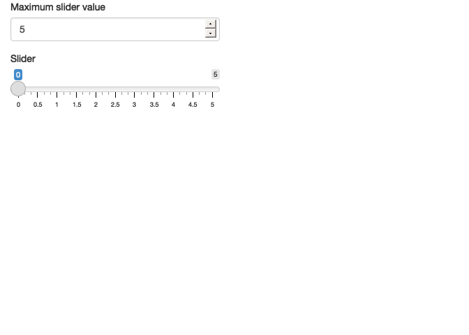

```r
library(shiny)
ui <- fluidPage(
       numericInput("num", "Maximum slider value", 5),
       uiOutput("slider")
)
##
server <- function(input, output) {
      output$slider <- renderUI({
             sliderInput("slider", "Slider",
                         min = 0,
                         max = input$num,
                         value = 0)
  })
}
##
shinyApp(ui = ui, server = server)
```

We can see that whenever we change the value of the numeric input, the slider input is re-generated.

## 12.2 Use `uiOutput()` To Populate the Countries

We can use this concept in our app to populate the choices for the country selector. The country selector currently only holds 3 values that we manually entered, but instead we could render the country selector in the server and list all countries in the data set. To this end, we need to replace the `selectInput("countryInput", ...)` in the UI with

`uiOutput("countryOutput")`

So we add the following code to the server function:

```
output$countryOutput <- renderUI({
  selectInput("countryInput", "Country",
              sort(unique(bcl$Country)),
              selected = "CANADA")
})
```

Next we add the above code to the server function in the following App.

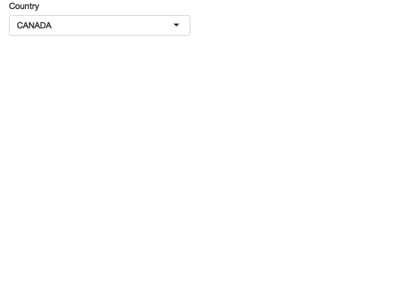

```r
library(shiny)
library(ggplot2)
library(dplyr)
## global statement
bcl <- read.csv("https://stat553.s3.amazonaws.com/Shiny/bcl-data.csv", stringsAsFactors = FALSE)
## UI function
ui <- fluidPage(
       uiOutput("countryOutput")
)
##
server <- function(input, output) {
      output$countryOutput <- renderUI({
                              selectInput("countryInput", "Country",
                              sort(unique(bcl$Country)),
                            selected = "CANADA")
      })
}
##
shinyApp(ui = ui, server = server)
```

We now can select all countries in the data set.

## 12.3 Handling NULL Value

Inside the filtered `reactive` function, we should check if the country input exists, and if not then just return NULL. This is because some of the functions such as `ggplot()` to be used inside the server function do not work with NULL.

```
filtered <- reactive({
  if (is.null(input$countryInput)) {
    return(NULL)
  }
  # if the above condition is not met, continue the
  # following filtering.
  bcl %>%
    filter(Price >= input$priceInput[1],
           Price <= input$priceInput[2],
           Type == input$typeInput,
           Country == input$countryInput
    )
})
```

When the `render function` tries to access the data, it will get a NULL value before the app is fully loaded. As mentioned earlier, the ggplot function does not work with a NULL data set, so we need to make a similar check in the `renderPlot()` function. Once the data is loaded, we can try to plot.

```
output$coolplot <- renderPlot({
  if (is.null(filtered())) {
    return()
  }
  ggplot(filtered(), aes(Alcohol_Content)) +
    geom_histogram()
})
```

The `renderTable()` function doesn’t need this fix applied because Shiny doesn’t have a problem rendering a NULL table.

## 12.4 Wrap-up Shiny App Code

In summary, we wrap up the previous code. The app is now functional, but there are plenty of features we can add to make it better.

[figure not shown]

```r
library(shiny)
library(ggplot2)
library(dplyr)
##
bcl <- read.csv("https://stat553.s3.amazonaws.com/Shiny/bcl-data.csv", stringsAsFactors = FALSE)
##
ui <- fluidPage(
  titlePanel("BC Liquor Store prices"),
  sidebarLayout(
    sidebarPanel(
        sliderInput("priceInput", "Price", 0, 100, c(25, 40), pre = "$"),
        radioButtons("typeInput", "Product type",
                     choices = c("BEER", "REFRESHMENT", "SPIRITS", "WINE"),
                     selected = "WINE"),
        uiOutput("countryOutput")
      ),
    mainPanel(
      plotOutput("coolplot"),
      br(), br(),
      tableOutput("results")
    )
  )
)
##
server <- function(input, output) {
    output$countryOutput <- renderUI({
       selectInput("countryInput", "Country",
                  sort(unique(bcl$Country)),
                  selected = "CANADA")
    })
  ##
  filtered <- reactive({
    if (is.null(input$countryInput)) {
      return(NULL)
    }
    ##
    bcl %>%
      filter(Price >= input$priceInput[1],
             Price <= input$priceInput[2],
             Type == input$typeInput,
             Country == input$countryInput
      )
  })
  ##
  output$coolplot <- renderPlot({
    if (is.null(filtered())) {
      return()
    }
    ggplot(filtered(), aes(Alcohol_Content)) +
      geom_histogram()
  })
  ##
  output$results <- renderTable({
       filtered()
    })
 }
##
shinyApp(ui = ui, server = server)
```

If you find this tutorial useful, please consider supporting me for the countless hours I’ve put into developing and maintaining my educational material :)

# 13 Share App

So far, we’ve been running Shiny locally. That is our computer was used to power the app. It also means that the app was not accessible to anyone on the internet. If we want to share our app with the world, we need to host it somewhere.

## 13.1 Host on `shinyapps.io`

RStudio provides a service called `shinyapps.io` which can host our apps for free. It is integrated seamlessly into RStudio so that we can publish our apps with the click of a button. It has both free and commercial versions.

The free version allows a certain number of apps per user and a certain number of activity on each app. It also allows us to see some basic stats about usage of our app.

Hosting your app on `shinyapps.io` is the easy and recommended way of getting your app online. Go to <www.shinyapps.io> and sign up for an account.

When we’re ready to publish our app, click on the “Publish Application” button in RStudio and follow their instructions. You might be asked to install a couple packages if it’s your first time.

After a successful deployment to `shinyapps.io`, you will be redirected to your app in the browser. You can use that URL to share your apps with anyone who can access the web page.

## 13.2 Host on a Shiny Server

The other option for hosting your app is on your own private Shiny server. Shiny Server is also a product by RStudio that allows us to host apps on our own server to get more freedom and flexibility.

# 14 More Shiny Features

Shiny is powerful and has lots of features that were not covered in this note. Here’s a sneak peek of just a few other common Shiny features.

## 14.1 Shiny in Rmarkdown

Just like this note, we can include Shiny inputs and outputs in an Rmarkdown document! In other words, Rmarkdown document can be interactive.

## 14.2 Use `ConditionalPanel()`

We can use `conditionalPanel()` to either show or hide a UI element based on a simple condition, such as the value of another input.

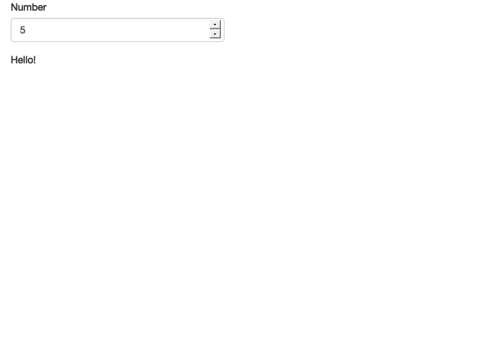

```r
library(shiny)
ui <- fluidPage(
  numericInput("num", "Number", 5, 1, 10),
  conditionalPanel(
    "input.num >=5",
    "Hello!"
  )
)
server <- function(input, output) {}
shinyApp(ui = ui, server = server)
```

## 14.3 UI with Multiple Tabs

We can use `navbarPage()` or `tabsetPanel()` to create multiple tabs in the UI. If our apps require more than a single “view”, we can create separate tabs.

The following simple example shows how to make multiple tabs in a UI.

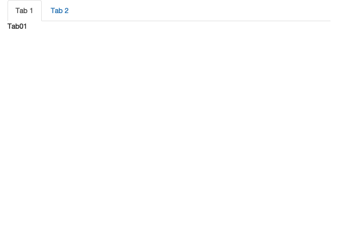

```r
library(shiny)
ui <- fluidPage(
  tabsetPanel(
    tabPanel("Tab 1", "Tab01"),
    tabPanel("Tab 2", "Tab02")
  )
)
server <- function(input, output) {}
shinyApp(ui = ui, server = server)
```

## 14.4 Update Input Values Programmatically

We can use `update*Input()` functions to update input values. For example, `NumericInput()` input function has an equivalent `updateNumericInput` function to update any of its parameters. See the following simple example.

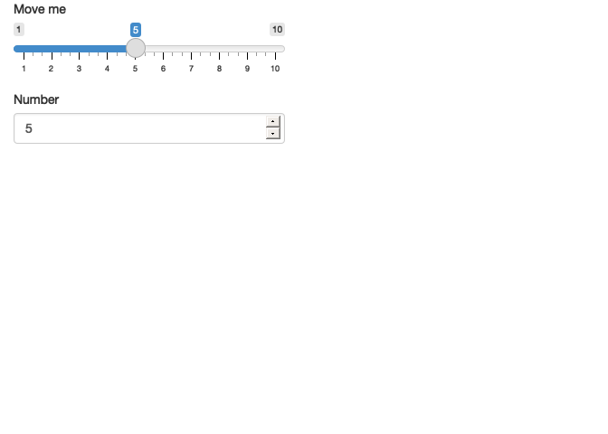

```r
library(shiny)
ui <- fluidPage(
  sliderInput("slider", "Move me", value = 5, 1, 10),
  numericInput("num", "Number", value = 5, 1, 10)
)
server <- function(input, output, session) {
  observe({
    updateNumericInput(session, "num", value = input$slider)
  })
}
shinyApp(ui = ui, server = server)
```

## 14.5 Global Objects

We can use global.R to define objects available to both ui.R and server.R. In other words, if we want to make some R objects available to both `ui.R` and `server.R`, we can place them in `global.R`. The relevant important concept is `scoping`.

## 14.6 Add Images

We can add an image to our Shiny app by placing an image under the “www/” folder and using the UI function img(src = “image.png”). Shiny will know to automatically look in the “www/” folder for the image.